# Statistical Rethinking Problems: Chapter 5

Simon Thornewill von Essen

2024-03-28

## 5e1

Which of the linear regressions below are multi-lms?

$$\mu_i \sim \alpha + \beta x_i \\
\mu_i \sim \beta_x x_i + \beta_z z_i \\
\mu_i \sim \alpha + \beta(x_i - z_i) \\
\mu_i \sim \alpha + \beta_x x_i + \beta_z z_i \\$$

This seems to be true, you need to have multiple slope parameters to have a multi-lm.

## 5e2

Write down a multiple regression to evaluate the claim: Animal diversity is linearly related to latitude, but only after controlling for plant diversity. You just need to write down the model definition.

$$\textrm{ad} \sim \textrm{N}(\mu_i, \sigma) \\
\mu_i = \alpha + \beta_l l_i + \beta_{pd}pd_i$$

## 5e3

Write down a multiple regression to evaluate the claim: Neither amount of funding nor size of laboratory is by itself a good predictor of time to PhD degree; but together these variables are both positively associated with time to degree. Write down the model definition and indicate which side of zero each slope parameter should be on.

You would need a couple of regressions.

1. $\mu_i \sim \alpha + \beta_f f_i$
2. $\mu_i \sim \alpha + \beta_s s_i$
3. $\mu_i \sim \alpha + \beta_ff_i + \beta_s s_i$

So then the coeficient for both $\beta_f$ and $\beta_s$ will be zero in models 1 and 2, but in model 3 they would be both positive.

## 5E4

Suppose you have a single categorical predictor with 4 levels (unique values), labeled A, B, C and D. Let Ai be an indicator variable that is 1 where case i is in category A. Also suppose Bi, Ci, and Di for the other categories. Now which of the following linear models are inferentially equivalent ways to include the categorical variable in a regression? Models are inferentially equivalent when it’s possible to compute one posterior distribution from the posterior distribution of another model.

$$(1)\ \mu_i = \alpha + \beta_A A_i + \beta_B B_i + \beta_D D_i \\
(2)\ \mu_i = \alpha + \beta_A A_i + \beta_B B_i + \beta_C C_i + \beta_D
D_i \\
(3)\ \mu_i = \alpha + \beta_B B_i + \beta_C C_i + \beta_D D_i \\
(4)\ \mu_i = \alpha A_i + \beta_B B_i + \beta_C C_i + \beta_D D_i \\
(5)\ \mu_i = \alpha (1 - B_i - C_i - D_i)+ \beta_B B_i + \beta_C C_i +
\beta_D D_i \\$$
For `1`, the C term gets absorbed into the intercept term (i.e. the intercept represents when all categories are false or C).

For `2`, the intercept represents when its none of the categories.

Meanwhile for `3` the intercept is when it’s none of the categories or A. It seems that `5` is equivalent even if it’s a weird way to write it.

In `4` there is no intercept and the $a\pha$ term is really a $\beta$ term.

It turns out that I’m wrong and `1`, `3`, `4`, `5` are all equivalent lmao. It was a little bit difficult to interpret.

## 5m1

Invent your own example of a spurious correlation. An outcome variable should be correlated with both predictor variables. But when both predictors are entered in the same model, the correlation between the outcome and one of the predictors should mostly vanish (or at least be greatly reduced). 5M2. Invent your own example of a masked relationship. An outcome variable should be correlated with both predictor variables, but in opposite directions.

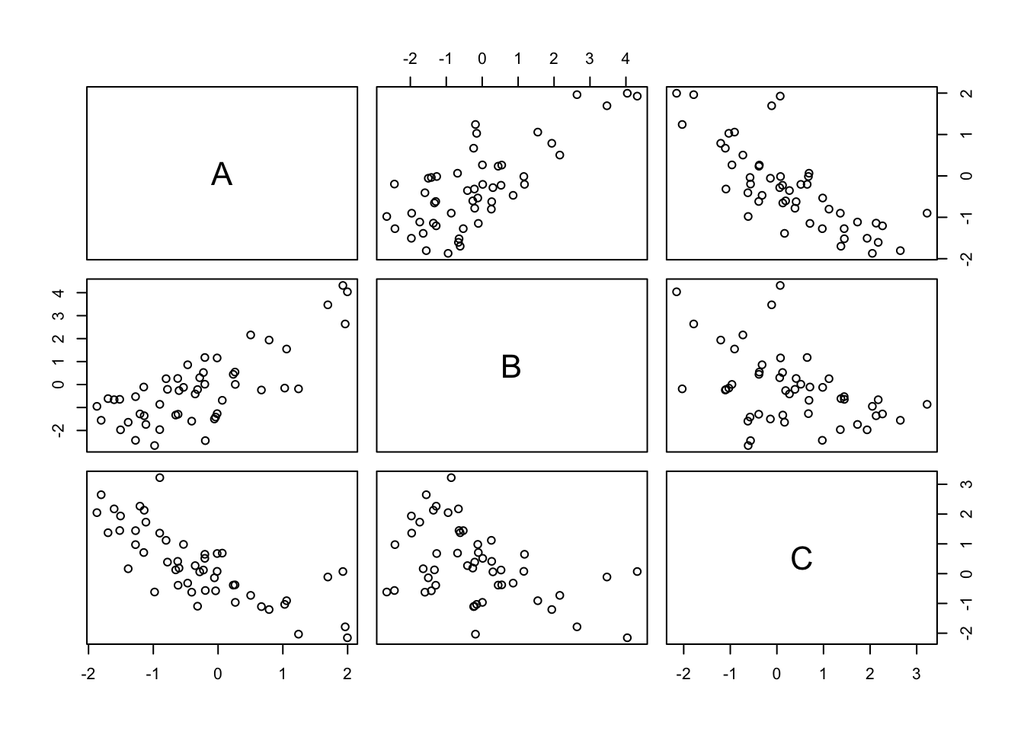

```r
A = rnorm(50)
B = rnorm(50, A)
C = rnorm(50, -A)

d.5m1 = data.frame(A=A, B=B, C=C)

pairs(~A + B + C, d.5m1)
```

We can see that B and A are related to each other, but we know from the code that it’s A that is causing both of them.

## 5m2

Invent your own example of a masked relationship. An outcome variable should be correlated with both predictor variables, but in opposite directions. And the two predictor variables should be correlated with one another.

[figure not shown]

```r
B = rnorm(50)
C = rnorm(50, B)
A = rnorm(50, B-C)

d.5m2 = data.frame(A=A, B=B, C=C)

pairs(~A + B + C, d.5m1)
```

But you also see how B and C have a correlation as well.

## 5M3

It is sometimes observed that the best predictor of fire risk is the presence of firefighters— States and localities with many firefighters also have more fires. Presumably firefighters do not cause fires. Nevertheless, this is not a spurious correlation. Instead fires cause firefighters. Consider the same reversal of causal inference in the context of the divorce and marriage data. How might a high divorce rate cause a higher marriage rate? Can you think of a way to evaluate this relationship, using multiple regression?

If there are more people who are divorced then you would expect that there are more single people who can marry again if they find someone else who they want to get married with. Therefore you can imagine that divorce can cause marriage.

I’d suppose you could use this regression.

$$M \sim \textrm{N}(\mu, \sigma) \\
\mu = \alpha M_i \\
\alpha_j \sim N(\mu_j, \sigma_j), \textrm{For}\ \alpha \in \{1, 2\}$$

Here, I created two parameters for M_i depending on how many times they were married. (Not at all or at least once.)

## 5M4

In the divorce data, States with high numbers of members of the Church of Jesus Christ of Latter-day Saints (LDS) have much lower divorce rates than the regression models expected.

Find a list of LDS population by State and use those numbers as a predictor variable, predicting divorce rate using marriage rate, median age at marriage, and percent LDS population (possibly standardized).

You may want to consider transformations of the raw percent LDS variable.

```r
data(WaffleDivorce)
d.5m4 = WaffleDivorce
d.5m4$pct_LDS = c(0.75, 4.53, 6.18, 1, 2.01, 2.82, 0.43, 0.55, 0.38,
0.75, 0.82, 5.18, 26.35, 0.44, 0.66, 0.87, 1.25, 0.77, 0.64, 0.81,
0.72, 0.39, 0.44, 0.58, 0.72, 1.14, 4.78, 1.29, 0.61, 0.37, 3.34,
0.41, 0.82, 1.48, 0.52, 1.2, 3.85, 0.4, 0.37, 0.83, 1.27, 0.75,
1.21, 67.97, 0.74, 1.13, 3.99, 0.92, 0.44, 11.5)

d.5m4$D = standardize(d.5m4$Divorce)
d.5m4$M = standardize(d.5m4$Marriage)
d.5m4$A = standardize(d.5m4$MedianAgeMarriage)
d.5m4$P= standardize(d.5m4$pct_LDS)
```

Now that we have the data, we want to make a regression…

```r
m.5m4 = quap(
  alist(
    D ~ dnorm(mu, sigma),
    mu <- a + bM*M + bA*A + bP*P,
    a ~ dnorm(0, 0.2),
    c(bM, bA, bP) ~ dnorm(0, 0.5),
    sigma ~ dunif(0, 50)
    ),
  data=d.5m4
)

precis(m.5m4)
```

```
##                mean         sd       5.5%      94.5%
## a      1.821888e-06 0.09248420 -0.1478058  0.1478094
## bM     3.579901e-02 0.14837098 -0.2013265  0.2729245
## bA    -6.881399e-01 0.14536095 -0.9204548 -0.4558251
## bP    -3.127996e-01 0.12029129 -0.5050483 -0.1205509
## sigma  7.375564e-01 0.07404495  0.6192182  0.8558945
```

We can see from this regression that the P is negatively correlated with divorce rates.

## 5m5

One way to reason through multiple causation hypotheses is to imagine detailed mechanisms through which predictor variables may influence outcomes. For example, it is sometimes argued that the price of gasoline (predictor variable) is positively associated with lower obesity rates (outcome variable). However, there are at least two important mechanisms by which the price of gas could  
reduce obesity. First, it could lead to less driving and therefore more exercise. Second, it could lead to less driving, which leads to less eating out, which leads to less consumption of huge restaurant meals. Can you outline one or more multiple regressions that address these two mechanisms? Assume you can have any predictor data you need.

We’d need to think about the following vectors of data: 1. Obsesity (O) 2. Driving (D) 3. Walking (W) 4. Eating Out (E)

We’re proposing a dag where both `W -> O` (i.e. decreases obesity) and `E -> O` (i.e. eating out causes obesity), We’re then thinking about how driving `D` causes these variables. There’s also the factor that the price of fuel `P` drives `D`. So this means we’re thinking of the following DAG.

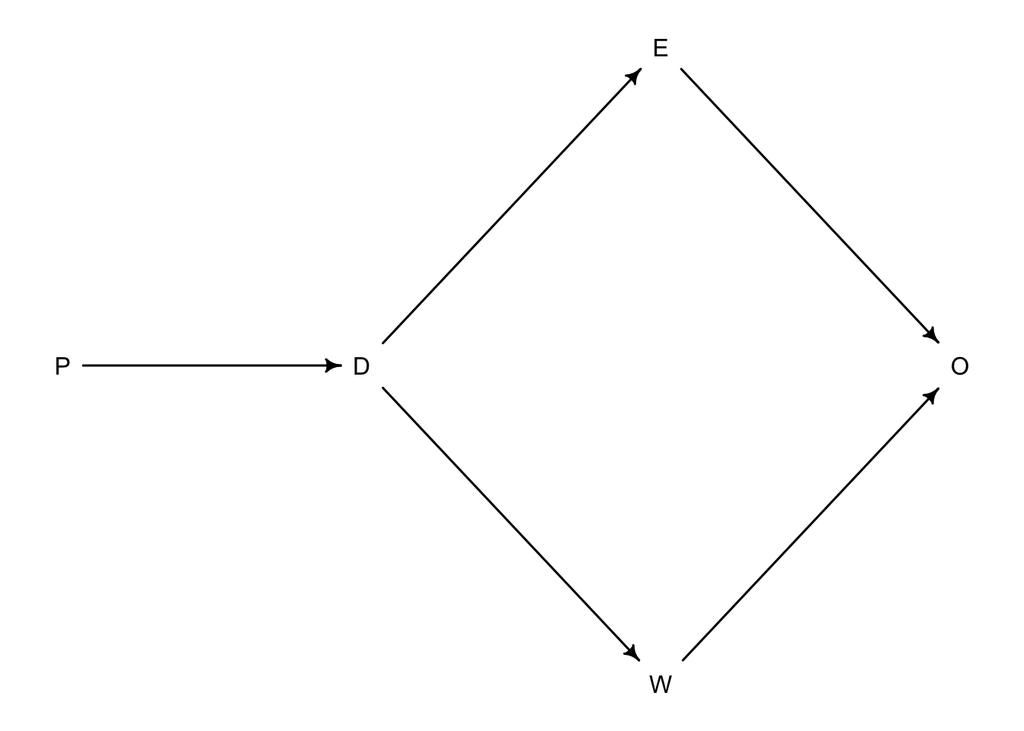

```r
dag.5m5 = dagitty( "dag{W -> O <- E  W <- D -> E P -> D}")
coordinates(dag.5m5) = list( x=c(P=-1, D=0,   W=1,   E=1,     O=2),
                             y=c(P=0,  D=0,   W=0.5, E =-0.5, O=0))

drawdag(dag.5m5)
```

So then we can make a couple of regressions:

1. `D ~ P`
2. `W ~ D`
3. `E ~ D`
4. `O ~ E + W`
5. `O ~ E`
6. `O ~ W`

There are ways that we can make this more complex, but this is the basic idea.

## 5H1

In the divorce example, suppose the DAG is: M → A → D. What are the implied conditional independencies of the graph? Are the data consistent with it?

```r
dag.5h1 = dagitty('dag{ D <- A <- M}')
impliedConditionalIndependencies(dag.5h1)
```

```
## D _||_ M | A
```

It seems that D can be conditionally independent of M given A. So let’s check that.

```r
m5h1 = quap(
  alist(
    D ~ dnorm(mu_i, sigma),
    mu_i <- a + bA*A + bM*M,
    a ~ dnorm(0, 0.2),
    c(bA, bM) ~ dnorm(0, 0.5),
    sigma ~ dexp(1)
  ),
  data = d.5m4
)

precis(m5h1)
```

```
##                mean         sd       5.5%      94.5%
## a      6.443754e-07 0.09707604 -0.1551456  0.1551469
## bA    -6.135142e-01 0.15098361 -0.8548152 -0.3722132
## bM    -6.538138e-02 0.15077308 -0.3063459  0.1755831
## sigma  7.851181e-01 0.07784343  0.6607093  0.9095270
```

We can see that the 89% CI includes 0 and so when we condition on A we do find that indeed the two are independent.

This shows that we have some evidence for this DAG being a possible mechanism for the data. (Although it’s a bit weird because here Marriage causes the median age at marriage which is a bit jank.)

## 5h2

Assuming that the DAG for the divorce example is indeed M → A → D, fit a new model and use it to estimate the counterfactual effect of halving a State’s marriage rate M. Use the counterfactual example from the chapter (starting on page 140) as a template.

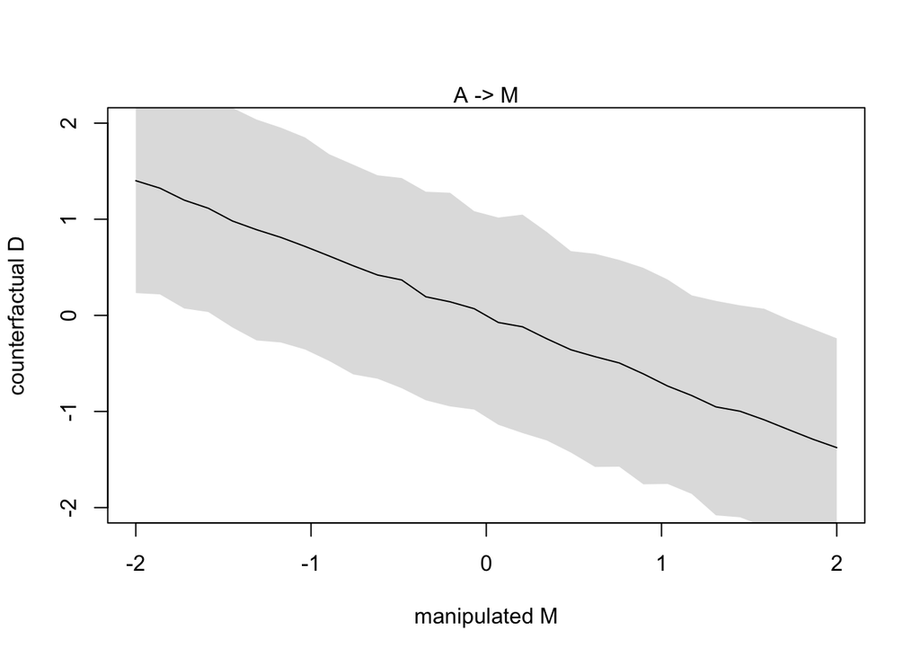

```r
m.5h2 = quap(
  alist(
    ## A -> D
    D ~ dnorm(mu, sigma),
    mu <- a + bA*A,
    a ~ dnorm(0, 0.2),
    bA ~ dnorm(0, 0.5),
    sigma ~ dexp(1),

    ## M -> A
    A ~ dnorm(mu_A, sigma_A),
    mu_A <- aA + bMA*M,
    aA ~ dnorm(0, 0.2),
    bMA ~ dnorm(0, 0.5),
    sigma_A ~ dexp(1)
  ),
  data = d.5m4
)

M_seq = seq(from=-2, to=2, length.out=30)

sim_dat = data.frame(M=M_seq)
# The wording from the text implies that we're using the simulated values of A
# to simulate D
s = sim(m.5h2, data=sim_dat, vars=c("A", "D"))

plot(sim_dat$M, colMeans(s$A), ylim=c(-2, 2), type="l",
     xlab="manipulated M", ylab="counterfactual D")
shade(apply(s$A, 2, PI), sim_dat$M)
mtext("A -> M")
```

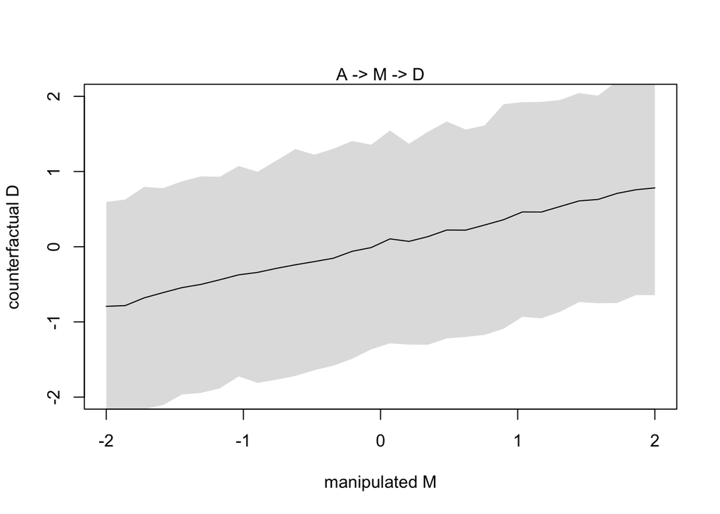

```r
plot(sim_dat$M, colMeans(s$D), ylim=c(-2, 2), type="l",
     xlab="manipulated M", ylab="counterfactual D")
shade(apply(s$D, 2, PI), sim_dat$M)
mtext("A -> M -> D")
```

## 5h3

Return to the milk energy model, m5.7. Suppose that the true causal relationship among the variables is:

```
M -> K <- N
M -> N
```

Now compute the counterfactual effect on K of doubling M. You will need to account for both the direct and indirect paths of causation. Use the counterfactual example from the chapter (starting on page 140) as a template.

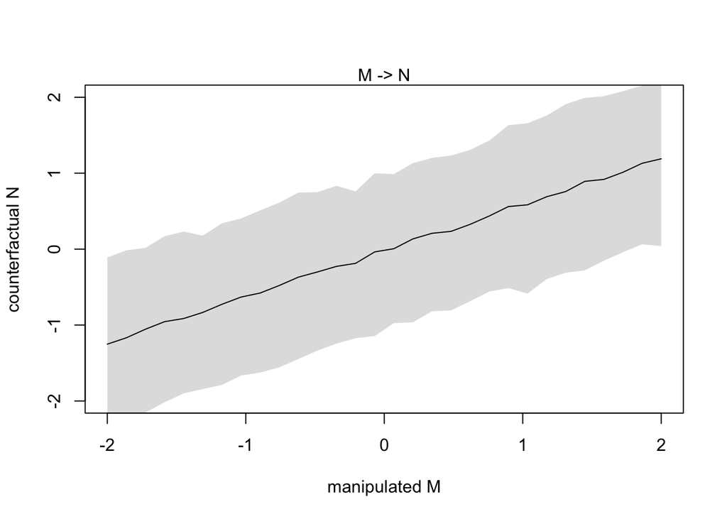

```r
data(milk)
d.m = milk

d.m$K = standardize( d.m$kcal.per.g)
d.m$N = standardize( d.m$neocortex.perc)
d.m$M = standardize( log(d.m$mass))

d.5h3 = d.m[complete.cases(d.m$K, d.m$N, d.m$M),]

m.5h3 = quap(
  alist(
    ## M -> K <- N
    K ~ dnorm(mu, sigma),
    mu <- a + bM*M + bN*N,
    a ~ dnorm(0, 0.2),
    bM ~ dnorm(0, 0.5),
    bN ~ dnorm(0, 0.5),
    sigma ~ dexp(1),

    ## M -> N
    N ~ dnorm(mu_N, sigma_N),
    mu_N <- aN + bMN*M,
    aN ~ dnorm(0, 0.2),
    bMN ~ dnorm(0, 0.5),
    sigma_N ~ dexp(1)
  ),
  data = d.5h3
)

M_seq = seq(from=-2, to=2, length.out=30)

sim_dat = data.frame(M=M_seq)
s = sim(m.5h3, data=sim_dat, vars=c("N", "K"))

plot(sim_dat$M, colMeans(s$N), ylim=c(-2, 2), type="l",
     xlab="manipulated M", ylab="counterfactual N")
shade(apply(s$N, 2, PI), sim_dat$M)
mtext("M -> N")
```

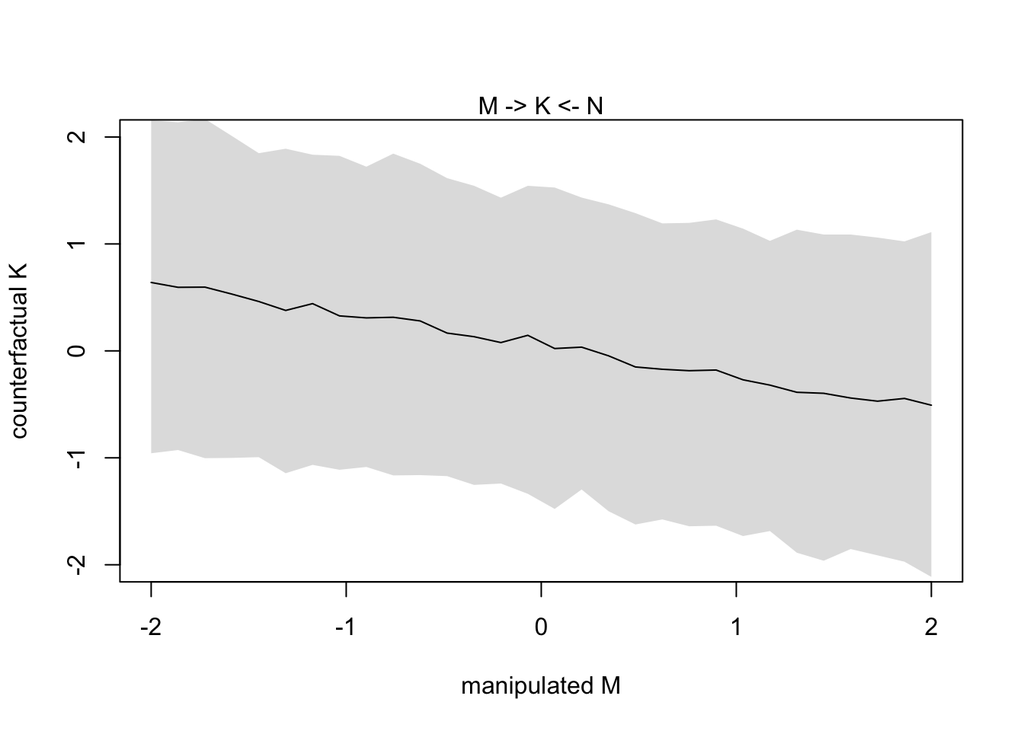

```r
plot(sim_dat$M, colMeans(s$K), ylim=c(-2, 2), type="l",
     xlab="manipulated M", ylab="counterfactual K")
shade(apply(s$K, 2, PI), sim_dat$M)
mtext("M -> K <- N")
```

## 5h4

Here is an open practice problem to engage your imagination. In the divorce date, States in the southern United States have many of the highest divorce rates. Add the South indicator variable to the analysis. First, draw one or more DAGs that represent your ideas for how Southern Americanculture might influence any of the other three variables (D, M or A). Then list the testable implications of your DAGs, if there are any, and fit one or more models to evaluate the implications. What do you think the influence of “Southerness” is?

Skipping this for next chapter.